# PC_2

Franco Hurtado Aguilar

2022-11-05

```r
library(dplyr)
library(rio)
library(car)
data <- import("wvs_brasil.xlsx")
```

A. A. Prepare las siguientes 15 variables (Columnas 91-105) para aplicar el análisis factorial exploratorio, eliminando valores indeseados y ordenando las categorías de forma ascendente. Explique la necesidad de este procedimiento.

```r
confianza <- data[,c(91:105)]
any(is.na(confianza))
```

```
## [1] FALSE
```

```r
confianza[confianza== -2] <- NA
confianza[confianza== -1] <- NA
confianza=na.omit(confianza)

confianza$`Q64: Confidence: Churches` <- recode(confianza$`Q64: Confidence: Churches`, "1=4 ; 2=3 ; 3=2 ; 4=1")

confianza$`Q65: Confidence: Armed Forces` <- recode(confianza$`Q65: Confidence: Armed Forces`, "1=4 ; 2=3 ; 3=2 ; 4=1")

confianza$`Q66: Confidence: The Press` <- recode(confianza$`Q66: Confidence: The Press`, "1=4 ; 2=3 ; 3=2 ; 4=1")

confianza$`Q67: Confidence: Television` <- recode(confianza$`Q67: Confidence: Television`, "1=4 ; 2=3 ; 3=2 ; 4=1")

confianza$`Q68: Confidence: Labor Unions` <- recode(confianza$`Q68: Confidence: Labor Unions`, "1=4 ; 2=3 ; 3=2 ; 4=1")

confianza$`Q69: Confidence: The Police` <- recode(confianza$`Q69: Confidence: The Police`, "1=4 ; 2=3 ; 3=2 ; 4=1")

confianza$`Q70: Confidence: Justice System/Courts` <- recode(confianza$`Q70: Confidence: Justice System/Courts`, "1=4 ; 2=3 ; 3=2 ; 4=1")

confianza$`Q71: Confidence: The Government` <- recode(confianza$`Q71: Confidence: The Government`, "1=4 ; 2=3 ; 3=2 ; 4=1")

confianza$`Q72: Confidence: The Political Parties` <- recode(confianza$`Q72: Confidence: The Political Parties`, "1=4 ; 2=3 ; 3=2 ; 4=1")

confianza$`Q73: Confidence: Parliament` <- recode(confianza$`Q73: Confidence: Parliament`, "1=4 ; 2=3 ; 3=2 ; 4=1")

confianza$`Q74: Confidence: The Civil Services` <- recode(confianza$`Q74: Confidence: The Civil Services`, "1=4 ; 2=3 ; 3=2 ; 4=1")

confianza$`Q75: Confidence: Universities` <- recode(confianza$`Q75: Confidence: Universities`, "1=4 ; 2=3 ; 3=2 ; 4=1")

confianza$`Q76: Confidence: Elections` <- recode(confianza$`Q76: Confidence: Elections`, "1=4 ; 2=3 ; 3=2 ; 4=1")

confianza$`Q77: Confidence: Major Companies` <- recode(confianza$`Q77: Confidence: Major Companies`, "1=4 ; 2=3 ; 3=2 ; 4=1")

confianza$`Q78: Confidence: Banks` <- recode(confianza$`Q78: Confidence: Banks`, "1=4 ; 2=3 ; 3=2 ; 4=1")
```

En primer lugar, hemos creado una subdata para que los cambios que hemos realizado no afecten nuestra data principal en caso sea necesaria, además que permite realizar los tests y cálculos solo para las variables que nos concierne. Eliminamos los valores no necesarios y se ordenaron las categorías de manera ascendente para poder tener una interpretación directa gracias a la escala positiva.

B. B. Aplique los pasos necesarios para el análisis factorial, explicando los resultados obtenidos en el proceso: (15 pts)

1. Presente la Matriz de correlaciones.

```r
library(polycor)
corMatrix=polycor::hetcor(confianza)$correlations
corMatrix
```

```
##                                        Q64: Confidence: Churches
## Q64: Confidence: Churches                              1.0000000
## Q65: Confidence: Armed Forces                          0.3144725
## Q66: Confidence: The Press                             0.2579397
## Q67: Confidence: Television                            0.2539016
## Q68: Confidence: Labor Unions                          0.1987561
## Q69: Confidence: The Police                            0.2221061
## Q70: Confidence: Justice System/Courts                 0.2265379
## Q71: Confidence: The Government                        0.1657238
## Q72: Confidence: The Political Parties                 0.1553449
## Q73: Confidence: Parliament                            0.1373442
## Q74: Confidence: The Civil Services                    0.2066627
## Q75: Confidence: Universities                          0.1795964
## Q76: Confidence: Elections                             0.1523519
## Q77: Confidence: Major Companies                       0.2523047
## Q78: Confidence: Banks                                 0.2571922
##                                        Q65: Confidence: Armed Forces
## Q64: Confidence: Churches                                  0.3144725
## Q65: Confidence: Armed Forces                              1.0000000
## Q66: Confidence: The Press                                 0.4000535
## Q67: Confidence: Television                                0.3231376
## Q68: Confidence: Labor Unions                              0.3065813
## Q69: Confidence: The Police                                0.4945325
## Q70: Confidence: Justice System/Courts                     0.4238445
## Q71: Confidence: The Government                            0.2488255
## Q72: Confidence: The Political Parties                     0.1744060
## Q73: Confidence: Parliament                                0.2178462
## Q74: Confidence: The Civil Services                        0.3141904
## Q75: Confidence: Universities                              0.3320773
## Q76: Confidence: Elections                                 0.2404935
## Q77: Confidence: Major Companies                           0.3469102
## Q78: Confidence: Banks                                     0.3207657
##                                        Q66: Confidence: The Press
## Q64: Confidence: Churches                               0.2579397
## Q65: Confidence: Armed Forces                           0.4000535
## Q66: Confidence: The Press                              1.0000000
## Q67: Confidence: Television                             0.6980611
## Q68: Confidence: Labor Unions                           0.4026838
## Q69: Confidence: The Police                             0.3530634
## Q70: Confidence: Justice System/Courts                  0.4155574
```

[output cut: 185 more lines]

```
## Q64: Confidence: Churches                           0.2571922
## Q65: Confidence: Armed Forces                       0.3207657
## Q66: Confidence: The Press                          0.3383754
## Q67: Confidence: Television                         0.3324323
## Q68: Confidence: Labor Unions                       0.3241724
## Q69: Confidence: The Police                         0.3488951
## Q70: Confidence: Justice System/Courts              0.3573221
## Q71: Confidence: The Government                     0.3370924
## Q72: Confidence: The Political Parties              0.2949900
## Q73: Confidence: Parliament                         0.3140319
## Q74: Confidence: The Civil Services                 0.3604491
## Q75: Confidence: Universities                       0.3663499
## Q76: Confidence: Elections                          0.3160364
## Q77: Confidence: Major Companies                    0.5257028
## Q78: Confidence: Banks                              1.0000000
```

La matriz de correlaciones nos permite observar qué variables tienen más correlación entre ellas, lo que se observa de mejor manera en el gráfico.

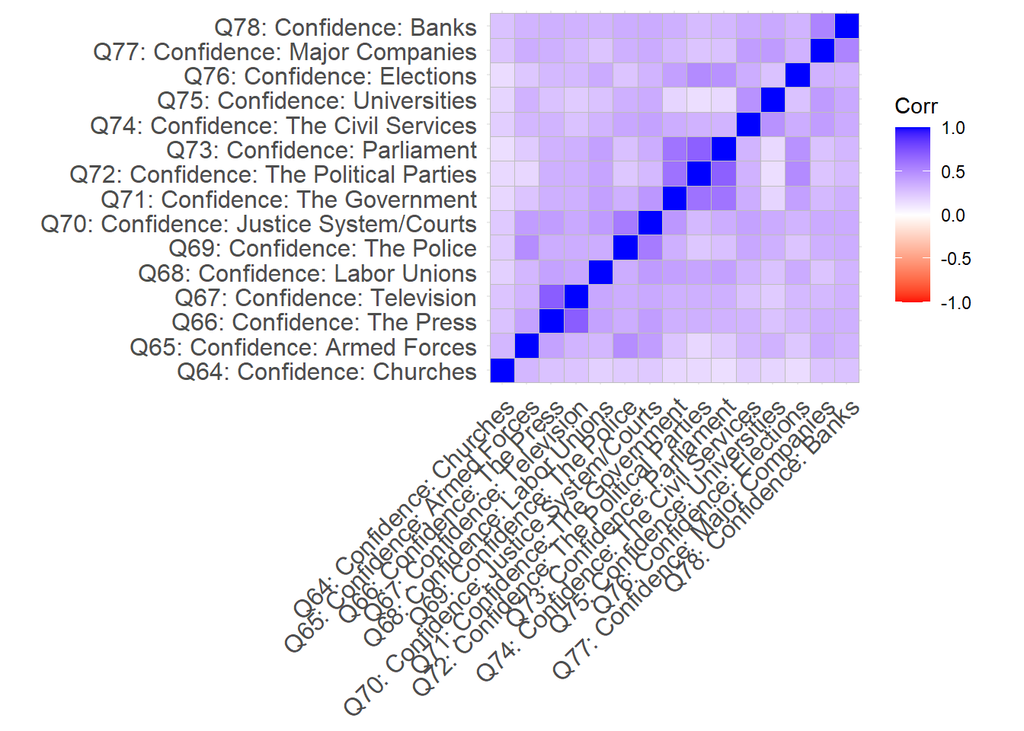

```r
library(ggcorrplot)
ggcorrplot(corMatrix,colors = c("#ff0000", "white", "#0000ff"))
```

Se observa en el gráfico que varias variables tienen un nivel de correlación medio a alto, lo que nos indica que el análisis factorial va a ser satisfactorio, no se observa correlaciones negativas.

2. Verifique los prerrequisitos (Factorización y Matriz de identidad).

Sin embargo, los resultados de la matriz de correlaciones no son suficientes para saber si es posible un análisis factorial, por lo que se realizarán las pruebas de factorización y matriz de identidad.

```r
library(psych)
KMO(corMatrix)
```

```
## Kaiser-Meyer-Olkin factor adequacy
## Call: KMO(r = corMatrix)
## Overall MSA =  0.9
## MSA for each item =
##              Q64: Confidence: Churches          Q65: Confidence: Armed Forces
##                                   0.93                                   0.91
##             Q66: Confidence: The Press            Q67: Confidence: Television
##                                   0.84                                   0.83
##          Q68: Confidence: Labor Unions            Q69: Confidence: The Police
##                                   0.96                                   0.89
## Q70: Confidence: Justice System/Courts        Q71: Confidence: The Government
##                                   0.91                                   0.92
## Q72: Confidence: The Political Parties            Q73: Confidence: Parliament
##                                   0.85                                   0.88
##    Q74: Confidence: The Civil Services          Q75: Confidence: Universities
##                                   0.93                                   0.89
##             Q76: Confidence: Elections       Q77: Confidence: Major Companies
##                                   0.94                                   0.90
##                 Q78: Confidence: Banks
##                                   0.92
```

Esta prueba nos permite confirmar si nuestras variables pueden ser factorizadas comparando los coeficientes de correlación, gracias a que el Overall MSA obtenido es mayor de 0.5, confirmamos que es posible la factorización.

Siguientemente, tenemos que verificar que la matriz de correlaciones obtenida no sea una matriz de identidad. La prueba de Bartlett evalúa la hipótesis de que la matriz sea de identidad, lo que indicaría que las variables no pueden ser agrupadas en factores.

```r
cortest.bartlett(corMatrix,n=nrow(confianza))$p.value>0.05
```

```
## [1] FALSE
```

Gracias a que el p-value obtenido es menor a 0.05 se puede rechazar la hipótesis de que nuestra matriz sea de identidad, por lo que hemos satisfecho los prerrequisitos y podemos continuar al análisis factorial.

3. Determine y solicite componentes.

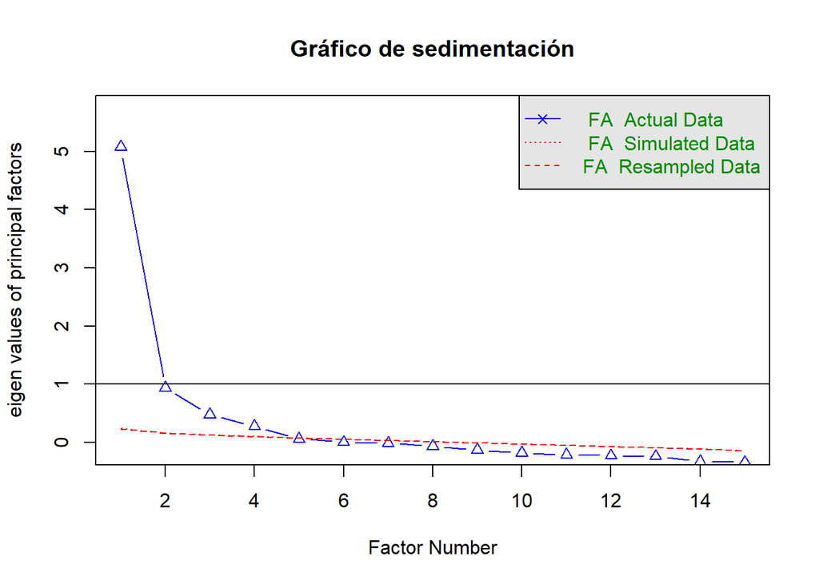

```
## Parallel analysis suggests that the number of factors =  4  and the number of components =  NA
```

```r
fa.parallel(confianza, fm="pa", fa="fa", main = "Gráfico de sedimentación")
```

```r
eigen<-eigen(cor(confianza, use="complete"))
eigen$values
```

```
##  [1] 5.7247384 1.5948676 1.1304693 0.9174263 0.8353729 0.6937040 0.6299154
##  [8] 0.6187551 0.5295256 0.4907271 0.4603172 0.4192070 0.3718161 0.3016188
## [15] 0.2815392
```

Para determinar el número de factores que se utilizarán, se realiza tanto el gráfico de sedimentación como el test de los eigen values. Para este caso, se elegirá utilizar 4 factores, ya que a pesar de que los eigen values nos indiquen que son 3, el gráfico de sedimentación indica que serían 4 y se obtará por el último ya que es necesaria una mayor cantidad de factores, considerando que estamos tratando con 15 variables distintas.

4. Evalúe el Análisis Factorial Exploratorio solicitado: ¿Qué variables aportaron más a los factores? ¿Qué variables contribuyen a más de un factor? ¿Qué variables tiene un componente “único” más grande?

Entonces, solicitamos el AFE mediante el método de rotación. Posteriormente observamos el resultado.

```r
library(GPArotation)
factorial <- fa(confianza,nfactors = 4,rotate = "varimax",fm="minres")
factorial
```

```
## Factor Analysis using method =  minres
## Call: fa(r = confianza, nfactors = 4, rotate = "varimax", fm = "minres")
## Standardized loadings (pattern matrix) based upon correlation matrix
##                                         MR2  MR1  MR4  MR3   h2   u2 com
## Q64: Confidence: Churches              0.07 0.25 0.18 0.22 0.15 0.85 3.0
## Q65: Confidence: Armed Forces          0.08 0.32 0.48 0.26 0.41 0.59 2.4
## Q66: Confidence: The Press             0.22 0.21 0.23 0.74 0.70 0.30 1.6
## Q67: Confidence: Television            0.24 0.16 0.18 0.76 0.69 0.31 1.4
## Q68: Confidence: Labor Unions          0.40 0.20 0.31 0.27 0.36 0.64 3.3
## Q69: Confidence: The Police            0.16 0.27 0.67 0.17 0.58 0.42 1.6
## Q70: Confidence: Justice System/Courts 0.28 0.27 0.62 0.19 0.57 0.43 2.1
## Q71: Confidence: The Government        0.67 0.16 0.25 0.14 0.56 0.44 1.5
## Q72: Confidence: The Political Parties 0.82 0.12 0.05 0.16 0.72 0.28 1.1
## Q73: Confidence: Parliament            0.78 0.12 0.13 0.15 0.66 0.34 1.2
## Q74: Confidence: The Civil Services    0.28 0.50 0.28 0.09 0.41 0.59 2.3
## Q75: Confidence: Universities          0.06 0.57 0.27 0.07 0.41 0.59 1.5
## Q76: Confidence: Elections             0.51 0.30 0.11 0.14 0.39 0.61 1.9
## Q77: Confidence: Major Companies       0.17 0.69 0.14 0.17 0.55 0.45 1.3
## Q78: Confidence: Banks                 0.24 0.55 0.17 0.20 0.43 0.57 1.9
##
##                        MR2  MR1  MR4  MR3
## SS loadings           2.56 1.92 1.58 1.55
## Proportion Var        0.17 0.13 0.11 0.10
## Cumulative Var        0.17 0.30 0.40 0.51
## Proportion Explained  0.34 0.25 0.21 0.20
## Cumulative Proportion 0.34 0.59 0.80 1.00
##
## Mean item complexity =  1.9
## Test of the hypothesis that 4 factors are sufficient.
##
## The degrees of freedom for the null model are  105  and the objective function was  5.69 with Chi Square of  7850.48
## The degrees of freedom for the model are 51  and the objective function was  0.14
##
## The root mean square of the residuals (RMSR) is  0.02
## The df corrected root mean square of the residuals is  0.03
##
## The harmonic number of observations is  1387 with the empirical chi square  113.08  with prob <  1.3e-06
## The total number of observations was  1387  with Likelihood Chi Square =  193.36  with prob <  1.9e-18
##
## Tucker Lewis Index of factoring reliability =  0.962
## RMSEA index =  0.045  and the 90 % confidence intervals are  0.038 0.052
## BIC =  -175.62
## Fit based upon off diagonal values = 1
## Measures of factor score adequacy
##                                                    MR2  MR1  MR4  MR3
## Correlation of (regression) scores with factors   0.91 0.81 0.79 0.86
## Multiple R square of scores with factors          0.82 0.66 0.63 0.73
## Minimum correlation of possible factor scores     0.65 0.31 0.26 0.47
```

```r
print(factorial$loadings)
```

```
##
## Loadings:
##                                        MR2   MR1   MR4   MR3
## Q64: Confidence: Churches                    0.252 0.185 0.221
## Q65: Confidence: Armed Forces                0.324 0.477 0.258
## Q66: Confidence: The Press             0.219 0.214 0.229 0.745
## Q67: Confidence: Television            0.244 0.158 0.181 0.756
## Q68: Confidence: Labor Unions          0.397 0.196 0.312 0.266
## Q69: Confidence: The Police            0.160 0.270 0.675 0.170
## Q70: Confidence: Justice System/Courts 0.284 0.267 0.620 0.194
## Q71: Confidence: The Government        0.670 0.156 0.254 0.143
## Q72: Confidence: The Political Parties 0.823 0.122       0.155
## Q73: Confidence: Parliament            0.782 0.119 0.131 0.145
## Q74: Confidence: The Civil Services    0.280 0.499 0.278
## Q75: Confidence: Universities                0.573 0.270
## Q76: Confidence: Elections             0.514 0.304 0.109 0.136
## Q77: Confidence: Major Companies       0.172 0.686 0.137 0.172
## Q78: Confidence: Banks                 0.241 0.549 0.169 0.201
##
##                  MR2   MR1   MR4   MR3
## SS loadings    2.557 1.919 1.578 1.546
## Proportion Var 0.170 0.128 0.105 0.103
## Cumulative Var 0.170 0.298 0.404 0.507
```

Podemos observar la cantidad que cada una de las variables aporta a los 4 factores solicitados.

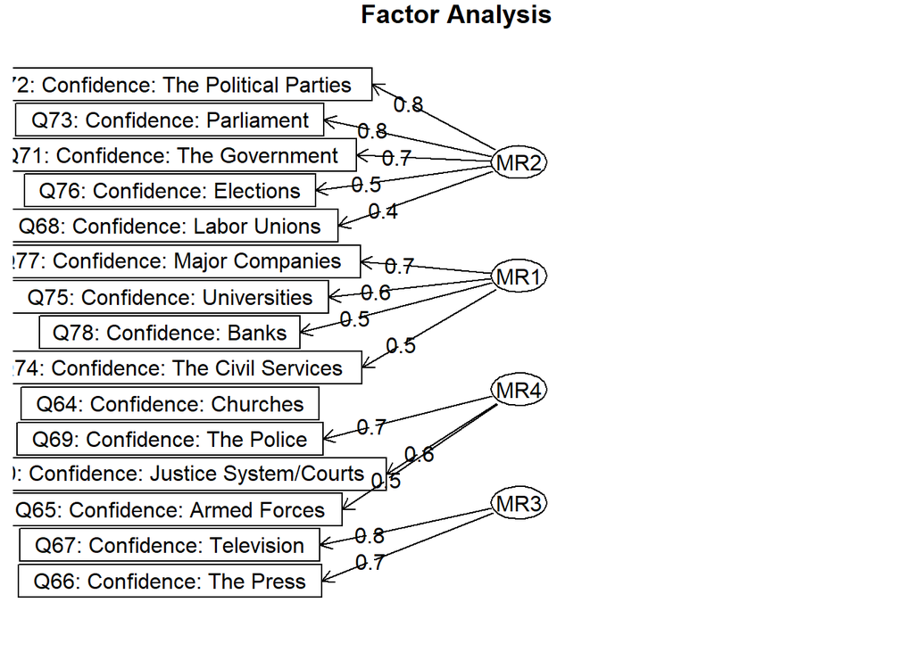

```r
fa.diagram(factorial)
```

Se observa entonces como se distribuyen los factores. El primero abordaría instituciones referentes a la participación política directa, el segundo a instituciones que aportan a la sociedad y en muchos casos son privadas, el tercero al sistema de justicia y orden, y el cuarto a los medios de comunicación. La variable de iglesia se encuentra separada ya que aporta menos a los factores, por lo que no ha sido posible agruparla en uno solo, pero se explica entendiendo la naturaleza de la iglesia, distinta a la encontrada en los demás factores.

¿Qué variables aportaron más a los factores?

```r
sort(factorial$communality)
```

```
##              Q64: Confidence: Churches          Q68: Confidence: Labor Unions
##                              0.1519880                              0.3647654
##             Q76: Confidence: Elections          Q65: Confidence: Armed Forces
##                              0.3873485                              0.4060892
##          Q75: Confidence: Universities    Q74: Confidence: The Civil Services
##                              0.4102277                              0.4124861
##                 Q78: Confidence: Banks       Q77: Confidence: Major Companies
##                              0.4283786                              0.5492454
##        Q71: Confidence: The Government Q70: Confidence: Justice System/Courts
##                              0.5586426                              0.5744343
##            Q69: Confidence: The Police            Q73: Confidence: Parliament
##                              0.5829915                              0.6641492
##            Q67: Confidence: Television             Q66: Confidence: The Press
##                              0.6883990                              0.7012174
## Q72: Confidence: The Political Parties
##                              0.7192709
```

Las variables que más aportaron a sus factores fueron las de partidos políticos, la prensa y la televisión. La variables de partidos políticos aporta al primera factor, mientras que prensa y televisión al último. Para la segunda variable, la variable que más aporta es la companías importantes, y para la tercera sería la policía.

¿Qué variables contribuyen a más de un factor?

```r
sort(factorial$complexity)
```

```
## Q72: Confidence: The Political Parties            Q73: Confidence: Parliament
##                               1.124184                               1.175155
##       Q77: Confidence: Major Companies            Q67: Confidence: Television
##                               1.345530                               1.429367
##          Q75: Confidence: Universities        Q71: Confidence: The Government
##                               1.490128                               1.506794
##             Q66: Confidence: The Press            Q69: Confidence: The Police
##                               1.561898                               1.585769
##                 Q78: Confidence: Banks             Q76: Confidence: Elections
##                               1.897538                               1.902696
## Q70: Confidence: Justice System/Courts    Q74: Confidence: The Civil Services
##                               2.050569                               2.290119
##          Q65: Confidence: Armed Forces              Q64: Confidence: Churches
##                               2.444720                               3.028595
##          Q68: Confidence: Labor Unions
##                               3.250923
```

Las variables que aportarían a más de un factor serían principalmente las de confianza en uniones laborales, la iglesia, fuerzas armadas, servicios civiles y cortes/sistemas de justicia.

¿Qué variables tiene un componente “único” más grande?

```r
sort(factorial$uniquenesses)
```

```
## Q72: Confidence: The Political Parties             Q66: Confidence: The Press
##                              0.2807291                              0.2987826
##            Q67: Confidence: Television            Q73: Confidence: Parliament
##                              0.3116010                              0.3358508
##            Q69: Confidence: The Police Q70: Confidence: Justice System/Courts
##                              0.4170085                              0.4255657
##        Q71: Confidence: The Government       Q77: Confidence: Major Companies
##                              0.4413574                              0.4507546
##                 Q78: Confidence: Banks    Q74: Confidence: The Civil Services
##                              0.5716214                              0.5875139
##          Q75: Confidence: Universities          Q65: Confidence: Armed Forces
##                              0.5897723                              0.5939108
##             Q76: Confidence: Elections          Q68: Confidence: Labor Unions
##                              0.6126515                              0.6352346
##              Q64: Confidence: Churches
##                              0.8480120
```

5. Guarde y estandarice los componentes.

En este paso generaremos una nueva subdata con los factores creados.

```r
factorial_casos<-as.data.frame(factorial$scores)
head(factorial_casos)
```

```
##          MR2        MR1         MR4        MR3
## 2  0.7983989 -0.5426782 -0.40227027 -1.0915858
## 4  1.8223722  0.1712826  0.09460302  0.6218767
## 5 -0.7851460  0.4495053  0.64854554 -1.2433126
## 6  1.8223722  0.1712826  0.09460302  0.6218767
## 8  0.8564037  0.5190806  0.56022693 -1.4773073
## 9 -0.5475011  0.2417456  1.48437059  0.4614039
```

```r
summary(factorial_casos)
```

```
##       MR2               MR1               MR4                MR3
##  Min.   :-1.3805   Min.   :-2.1455   Min.   :-2.83167   Min.   :-1.7651691
##  1st Qu.:-0.6896   1st Qu.:-0.5390   1st Qu.:-0.54795   1st Qu.:-0.7457617
##  Median :-0.3598   Median : 0.1477   Median : 0.08066   Median : 0.0000651
##  Mean   : 0.0000   Mean   : 0.0000   Mean   : 0.00000   Mean   : 0.0000000
##  3rd Qu.: 0.5809   3rd Qu.: 0.5503   3rd Qu.: 0.55225   3rd Qu.: 0.6583236
##  Max.   : 3.0933   Max.   : 2.0463   Max.   : 2.17348   Max.   : 2.6167331
```

Y también podemos incluirlos en la subdata en la que estuvimos trabajando.

```r
confianza$factor1<- factorial_casos$MR1
confianza$factor2<- factorial_casos$MR2
confianza$factor3<- factorial_casos$MR3
confianza$factor4<- factorial_casos$MR4
```

Finalmente, estandarizamos los factores para que la lectura de estos datos sea más sencilla de entender.

```r
library(BBmisc)
confianza$factor1_normalizado = normalize(confianza$factor1,
                                        method = "range",
                                        margin=2, # by column
                                        range = c(0, 100))
confianza$factor2_normalizado = normalize(confianza$factor2,
                                        method = "range",
                                        margin=2, # by column
                                        range = c(0, 100))
confianza$factor3_normalizado = normalize(confianza$factor3,
                                        method = "range",
                                        margin=2, # by column
                                        range = c(0, 100))
confianza$factor4_normalizado = normalize(confianza$factor4,
                                        method = "range",
                                        margin=2, # by column
                                        range = c(0, 100))
summary(confianza$factor1_normalizado)
```

```
##    Min. 1st Qu.  Median    Mean 3rd Qu.    Max.
##    0.00   38.33   54.71   51.18   64.31  100.00
```

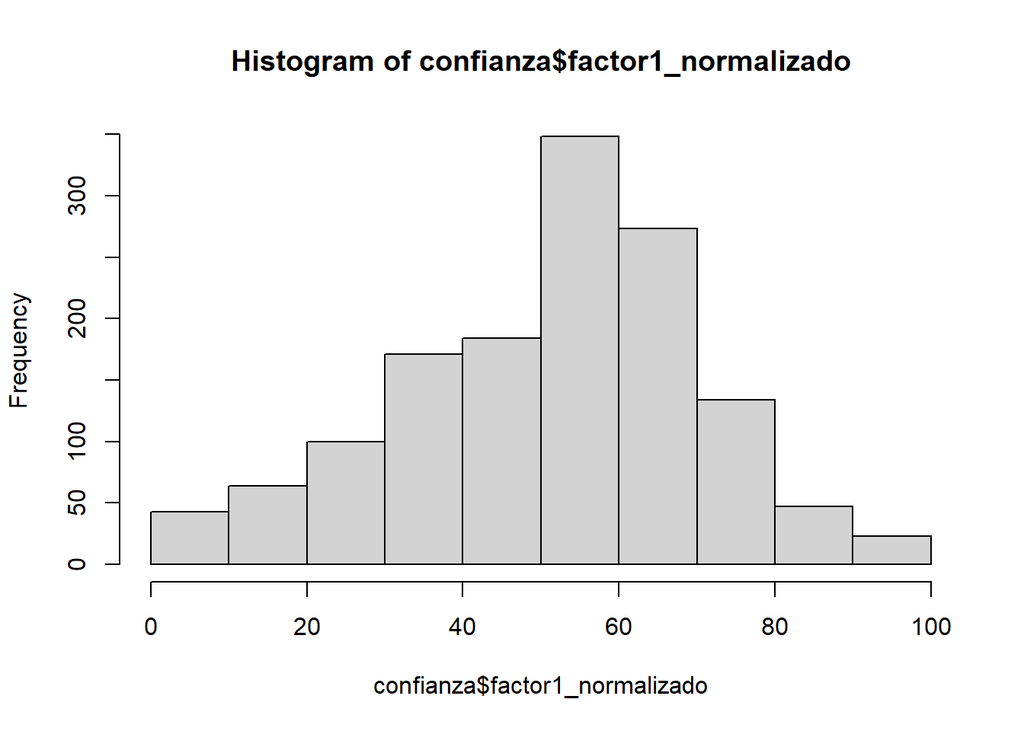

```r
hist(confianza$factor1_normalizado)
```